# What’s up with White Wine? by Cindy Wyant

The white wine dataset includes 11 different chemical attributes and 1 subjective quality score based on wine experts’ opinions, for a total of 12 data points for each of nearly 5,000 white wines.

The different chemical attributes are:  
1. Fixed Acidity  
2. Volatile Acidity  
3. Citric Acid  
4. Residual Sugar  
5. Chlorides  
6. Free Sulfur Dioxide  
7. Total Sulfur Dioxide  
8. Density  
9. pH  
10. Sulphates  
11. Alcohol

# Univariate Plots Section

```
##        X        fixed.acidity    volatile.acidity  citric.acid
##  Min.   :   1   Min.   : 3.800   Min.   :0.0800   Min.   :0.0000
##  1st Qu.:1225   1st Qu.: 6.300   1st Qu.:0.2100   1st Qu.:0.2700
##  Median :2450   Median : 6.800   Median :0.2600   Median :0.3200
##  Mean   :2450   Mean   : 6.855   Mean   :0.2782   Mean   :0.3342
##  3rd Qu.:3674   3rd Qu.: 7.300   3rd Qu.:0.3200   3rd Qu.:0.3900
##  Max.   :4898   Max.   :14.200   Max.   :1.1000   Max.   :1.6600
##  residual.sugar     chlorides       free.sulfur.dioxide
##  Min.   : 0.600   Min.   :0.00900   Min.   :  2.00
##  1st Qu.: 1.700   1st Qu.:0.03600   1st Qu.: 23.00
##  Median : 5.200   Median :0.04300   Median : 34.00
##  Mean   : 6.391   Mean   :0.04577   Mean   : 35.31
##  3rd Qu.: 9.900   3rd Qu.:0.05000   3rd Qu.: 46.00
##  Max.   :65.800   Max.   :0.34600   Max.   :289.00
##  total.sulfur.dioxide    density             pH          sulphates
##  Min.   :  9.0        Min.   :0.9871   Min.   :2.720   Min.   :0.2200
##  1st Qu.:108.0        1st Qu.:0.9917   1st Qu.:3.090   1st Qu.:0.4100
##  Median :134.0        Median :0.9937   Median :3.180   Median :0.4700
##  Mean   :138.4        Mean   :0.9940   Mean   :3.188   Mean   :0.4898
##  3rd Qu.:167.0        3rd Qu.:0.9961   3rd Qu.:3.280   3rd Qu.:0.5500
##  Max.   :440.0        Max.   :1.0390   Max.   :3.820   Max.   :1.0800
##     alcohol         quality
##  Min.   : 8.00   Min.   :3.000
##  1st Qu.: 9.50   1st Qu.:5.000
##  Median :10.40   Median :6.000
##  Mean   :10.51   Mean   :5.878
##  3rd Qu.:11.40   3rd Qu.:6.000
##  Max.   :14.20   Max.   :9.000
```

```
## 'data.frame':    4898 obs. of  13 variables:
##  $ X                   : int  1 2 3 4 5 6 7 8 9 10 ...
##  $ fixed.acidity       : num  7 6.3 8.1 7.2 7.2 8.1 6.2 7 6.3 8.1 ...
##  $ volatile.acidity    : num  0.27 0.3 0.28 0.23 0.23 0.28 0.32 0.27 0.3 0.22 ...
##  $ citric.acid         : num  0.36 0.34 0.4 0.32 0.32 0.4 0.16 0.36 0.34 0.43 ...
##  $ residual.sugar      : num  20.7 1.6 6.9 8.5 8.5 6.9 7 20.7 1.6 1.5 ...
##  $ chlorides           : num  0.045 0.049 0.05 0.058 0.058 0.05 0.045 0.045 0.049 0.044 ...
##  $ free.sulfur.dioxide : num  45 14 30 47 47 30 30 45 14 28 ...
##  $ total.sulfur.dioxide: num  170 132 97 186 186 97 136 170 132 129 ...
##  $ density             : num  1.001 0.994 0.995 0.996 0.996 ...
##  $ pH                  : num  3 3.3 3.26 3.19 3.19 3.26 3.18 3 3.3 3.22 ...
##  $ sulphates           : num  0.45 0.49 0.44 0.4 0.4 0.44 0.47 0.45 0.49 0.45 ...
##  $ alcohol             : num  8.8 9.5 10.1 9.9 9.9 10.1 9.6 8.8 9.5 11 ...
##  $ quality             : int  6 6 6 6 6 6 6 6 6 6 ...
```

Looking over the summary, it would seem I’m running into a ton of far outliers. Many of the variables’ 1st and 3rd quartiles are much further away from min and max respectively, than they are from one another (telling me most of the information is in the center there, but some points absolutely are not).

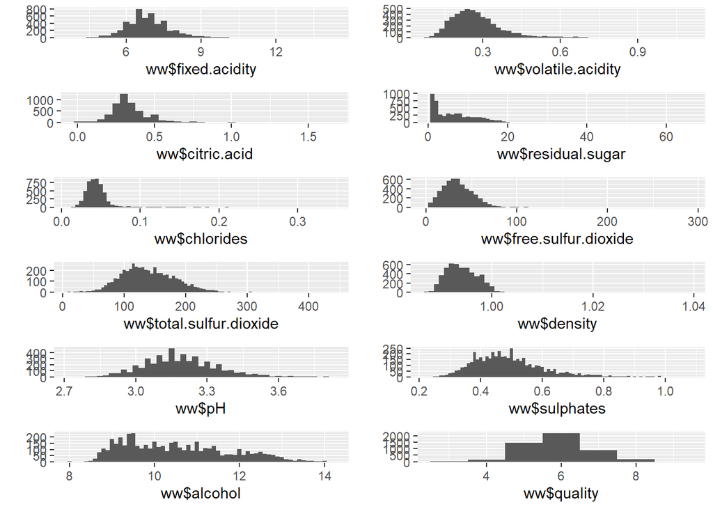

As far as charts go, the first thing I was really interested in seeing was a set of histograms so I can see each variable. This gives me a good idea of what I want to look into next. A few, such as citric acid and chlorides, have very long tails. Some others, like residual sugar and density, don’t have any visible high values but the charts are still formatted as though they do, so I’d like to see what’s going on there.

### Fixed Acidity

```
##    Min. 1st Qu.  Median    Mean 3rd Qu.    Max.
##   3.800   6.300   6.800   6.855   7.300  14.200
```

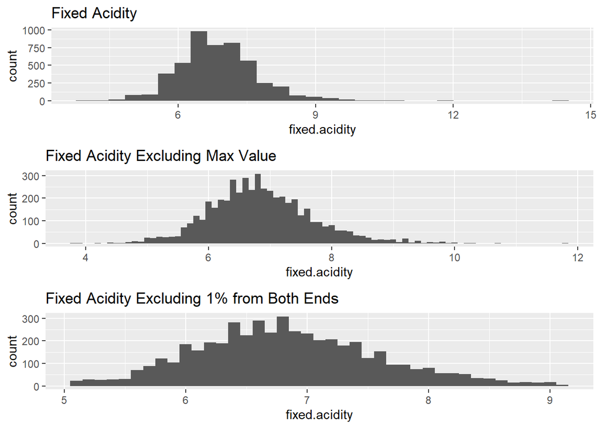

```
##    Min. 1st Qu.  Median    Mean 3rd Qu.    Max.
##   5.100   6.300   6.800   6.839   7.300   9.100
```

True to form! Fixed Acidity has extreme outliers on both ends. I tried the same plot while excluding ONLY the highest value data point, which helped, but I wanted to see how it would turn out after lopping percentages. Running the chart again while including only the central 98% looks like it makes a lot more sense.

The final summary is of that chunk of 98% of the data; the min and max have obviously changed drastically, but three of the four central stats are identical to those from the full set, and the fourth is extremely close (off by 0.016). I get concerned about how comfortable I feel excluding outliers, so seeing those summaries acts as validation in a sense.

### Volatile Acidity

```
##    Min. 1st Qu.  Median    Mean 3rd Qu.    Max.
##  0.0800  0.2100  0.2600  0.2782  0.3200  1.1000
```

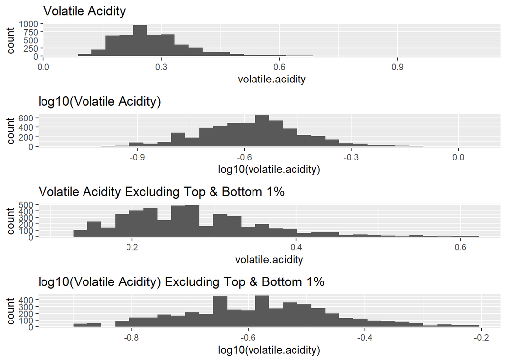

A lot of these variables are in the same boat in that they have one or a few extreme outliers. Log10 helps some of them look like a workable data model, but it’s definitely not always a fix.

### Citric Acid

```
##    Min. 1st Qu.  Median    Mean 3rd Qu.    Max.
##  0.0000  0.2700  0.3200  0.3342  0.3900  1.6600
```

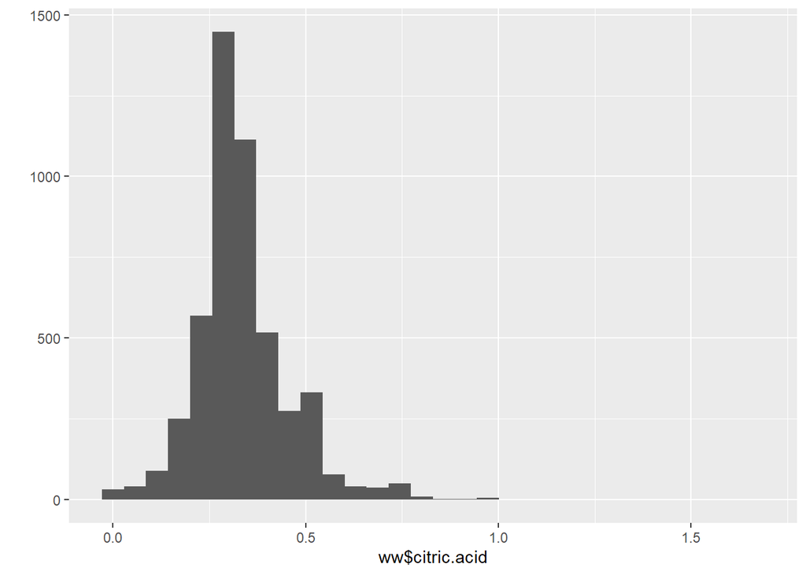

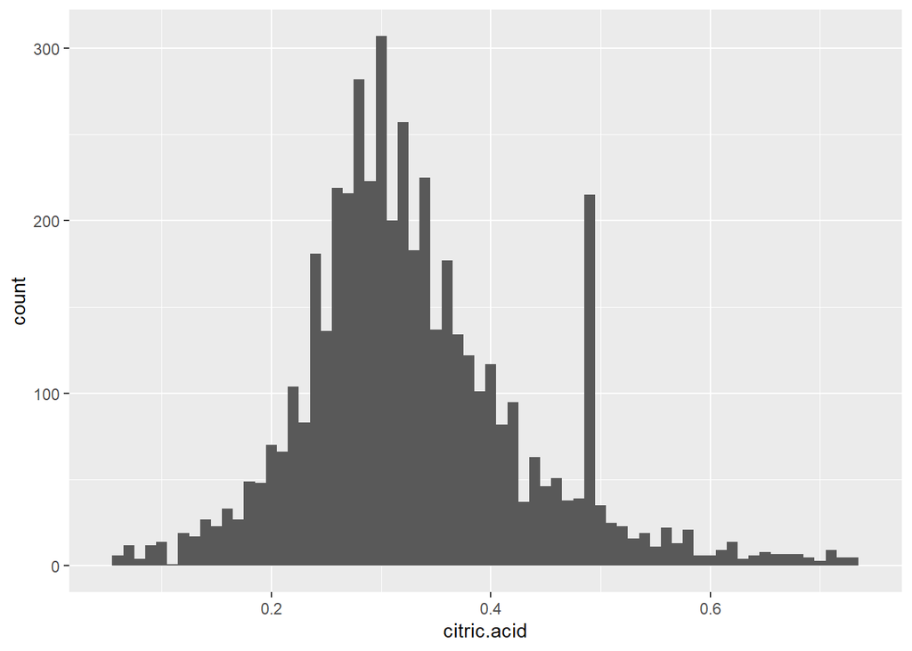

There’s a bit of a tail, but honestly it doesn’t seem significant. If I had to guess, that spike right before 0.5 is some sort of secondary standard (like the standard if the citric acid content is higher), so whether that’s from rounding or actual measurements, the amount doesn’t seem concerning.

What I just wrote was a valid explanation in my opinion, but I was still writing it partially to convince myself I don’t need to try log10. I did wind up trying and the table turned out far worse; results are below.

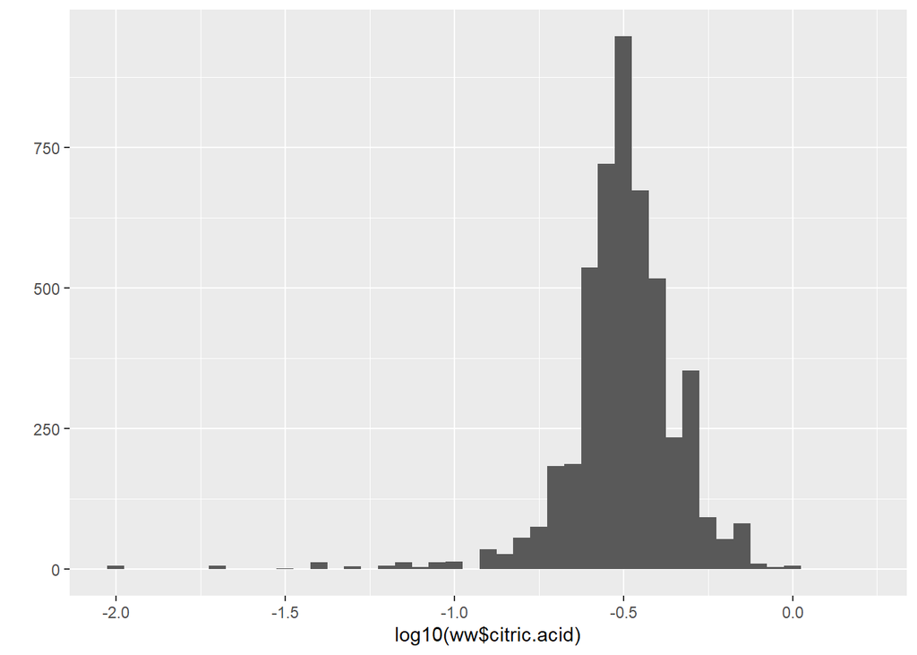

### Residual Sugar

```
##    Min. 1st Qu.  Median    Mean 3rd Qu.    Max.
##   0.600   1.700   5.200   6.391   9.900  65.800
```

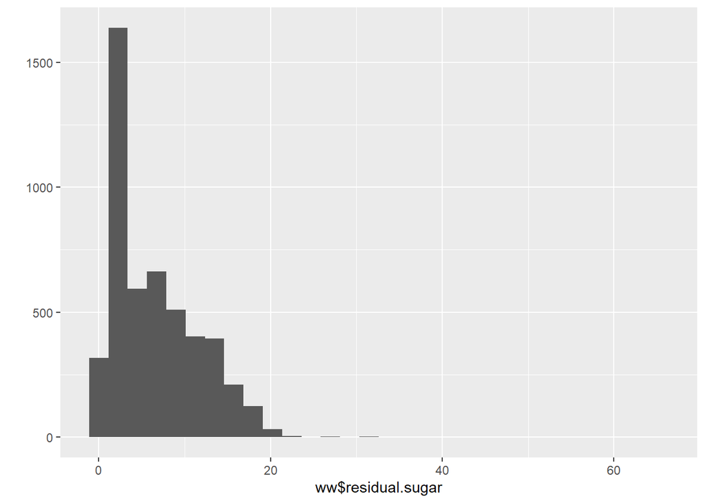

```
## , , volatile.acidity = 0.965, citric.acid = 0.6, residual.sugar = 65.8, chlorides = 0.074, free.sulfur.dioxide = 8, total.sulfur.dioxide = 160, density = 1.03898, pH = 3.39, sulphates = 0.69, alcohol = 11.7, quality = 6
##
##       fixed.acidity
## X      7.8
##   2782   1
```

Again, one value in this set is over double the second highest. I somewhat expected it to be the same record as the Sulfur Dioxide anomaly, but it’s a different one.

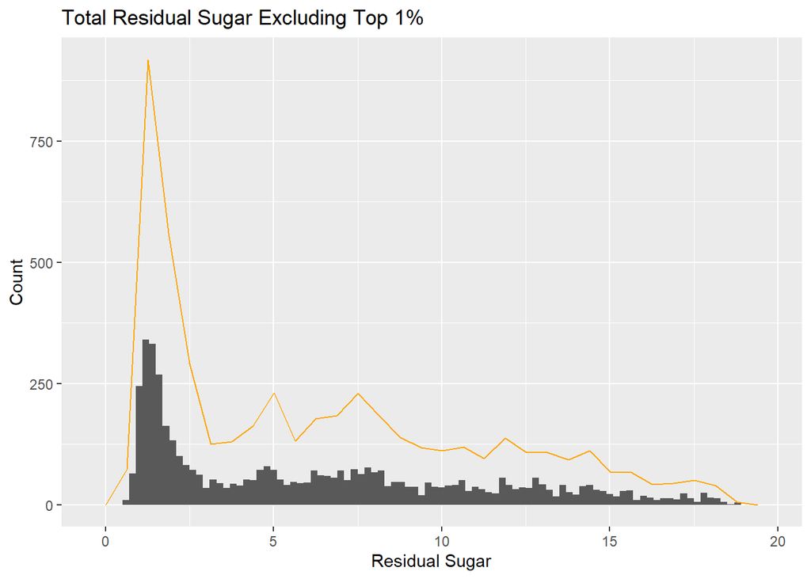

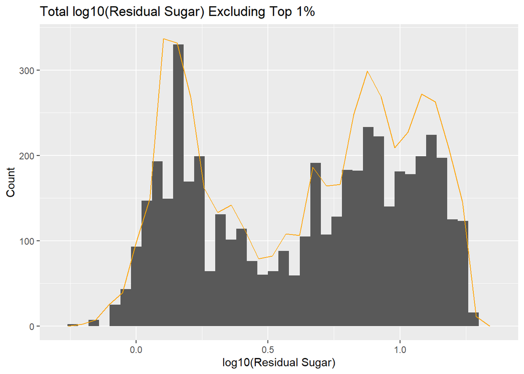

Excluding that top 1% gives a way better picture of the data, and it looks rife for a logging. Residual Sugar after a log10 transformation almost looks bimodal.

### Chlorides

```
##    Min. 1st Qu.  Median    Mean 3rd Qu.    Max.
## 0.00900 0.03600 0.04300 0.04577 0.05000 0.34600
```

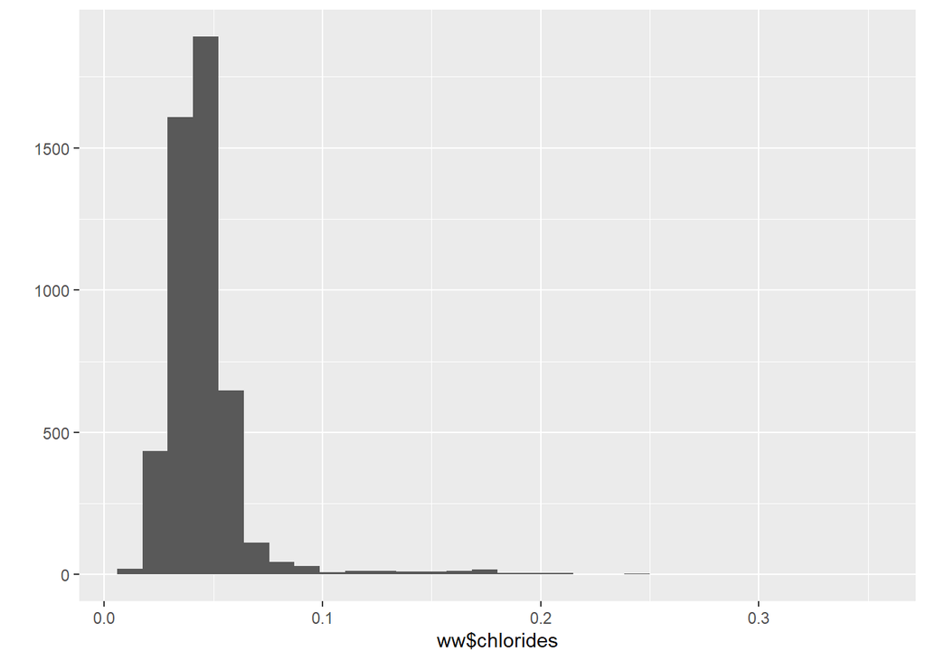

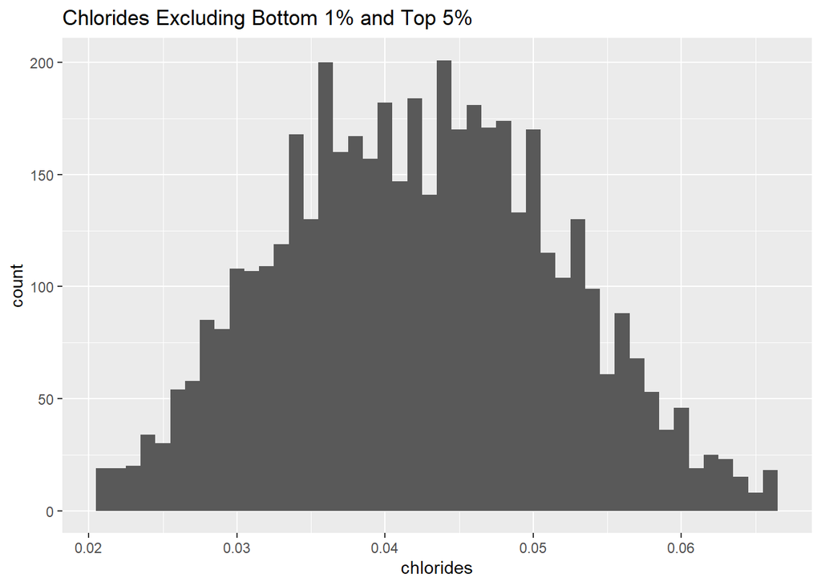

### Free Sulfur Dioxide

```
##    Min. 1st Qu.  Median    Mean 3rd Qu.    Max.
##    2.00   23.00   34.00   35.31   46.00  289.00
```

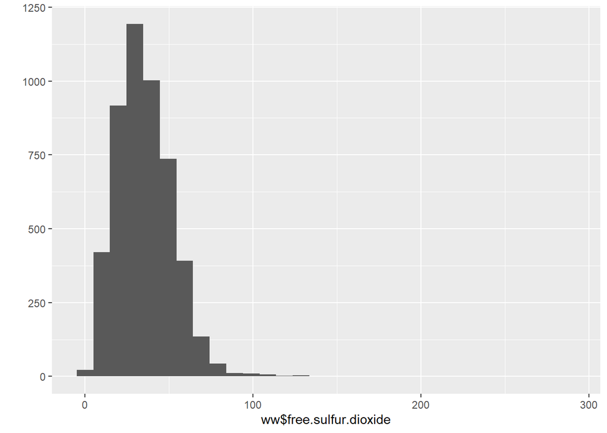

```
## 'data.frame':    1 obs. of  13 variables:
##  $ X                   : int 4746
##  $ fixed.acidity       : num 6.1
##  $ volatile.acidity    : num 0.26
##  $ citric.acid         : num 0.25
##  $ residual.sugar      : num 2.9
##  $ chlorides           : num 0.047
##  $ free.sulfur.dioxide : num 289
##  $ total.sulfur.dioxide: num 440
##  $ density             : num 0.993
##  $ pH                  : num 3.44
##  $ sulphates           : num 0.64
##  $ alcohol             : num 10.5
##  $ quality             : int 3
```

My data has the following to say about free sulfur dioxide:

> at free SO2 concentrations over 50 ppm,  
> SO2 becomes evident in the nose and taste of wine

If one of these actually does measure at 289, that’s well beyond the realm of reason. I’m ignoring this one for this variable, but I’m curious to see how it fares in the other categories. The second highest value is 146.5, still well beyond what’s expected; in total, 17 values are above 100. For now, I’ll just remove the highest, but I’ll keep those others in mind as I continue.

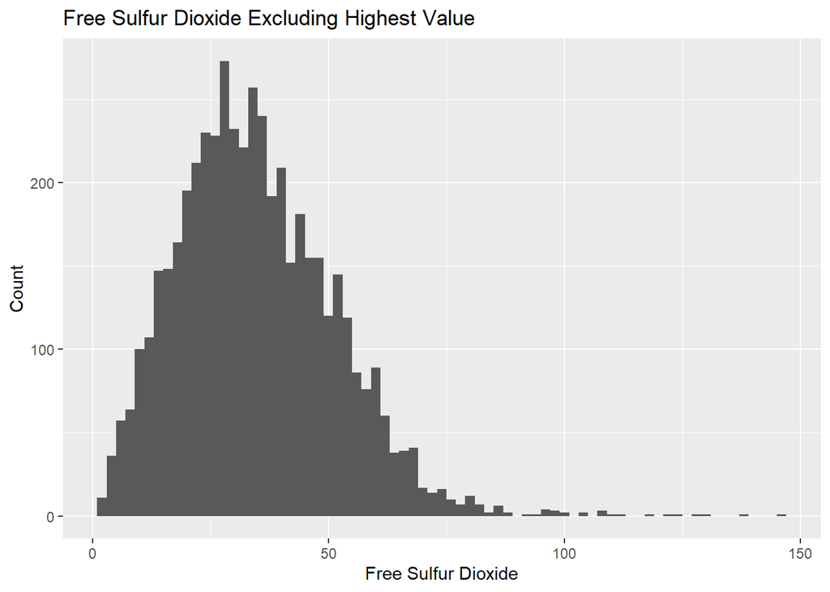

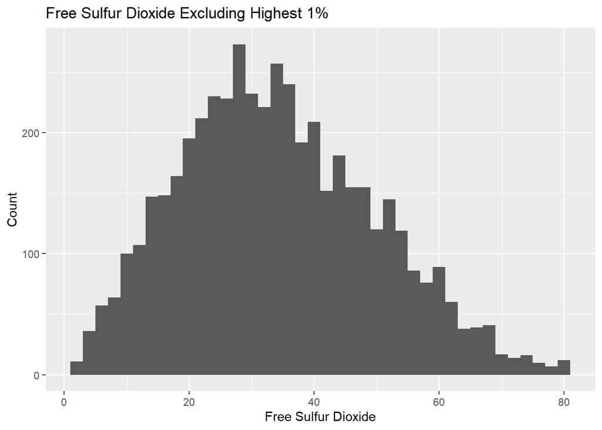

Again, I’m not positive what I’ll wind up doing with these, but I’ll likely want to check the oddly high values against quality later.

### Total Sulfur Dioxide

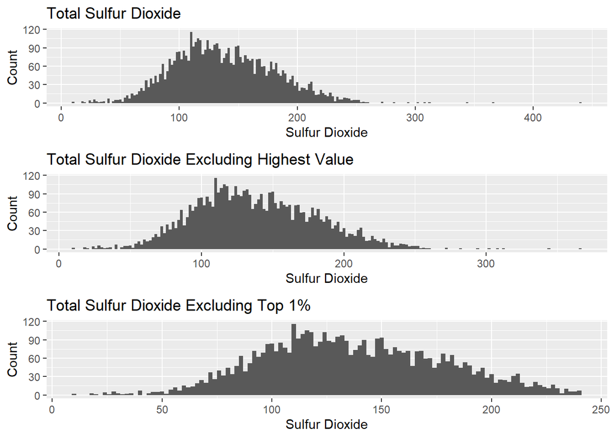

Predictably, Total Sulfur Dioxide follows the same pattern.

### Density

```
##    Min. 1st Qu.  Median    Mean 3rd Qu.    Max.
##  0.9871  0.9917  0.9937  0.9940  0.9961  1.0390
```

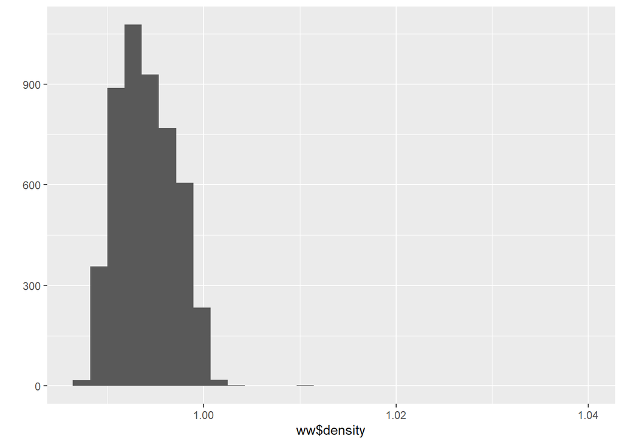

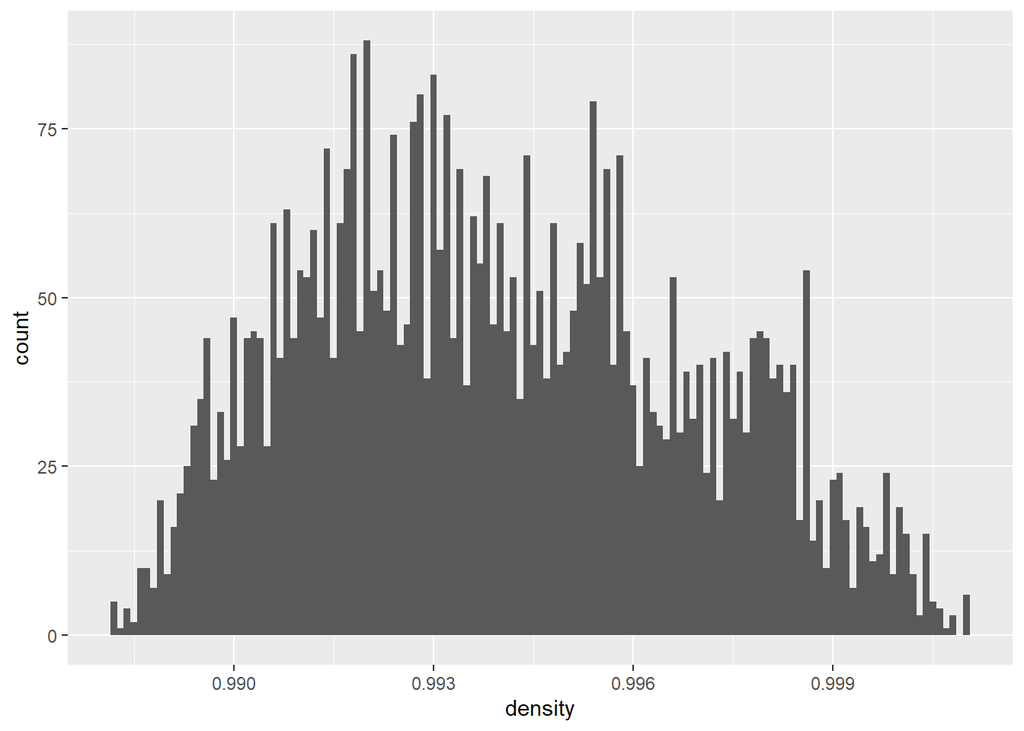

The summary makes it clear that Density falls squarely in the “extremely high outliers” camp. I didn’t have much luck with log10, but shaving off just 0.3% from each end made a huge difference.

### pH

```
##    Min. 1st Qu.  Median    Mean 3rd Qu.    Max.
##   2.720   3.090   3.180   3.188   3.280   3.820
```

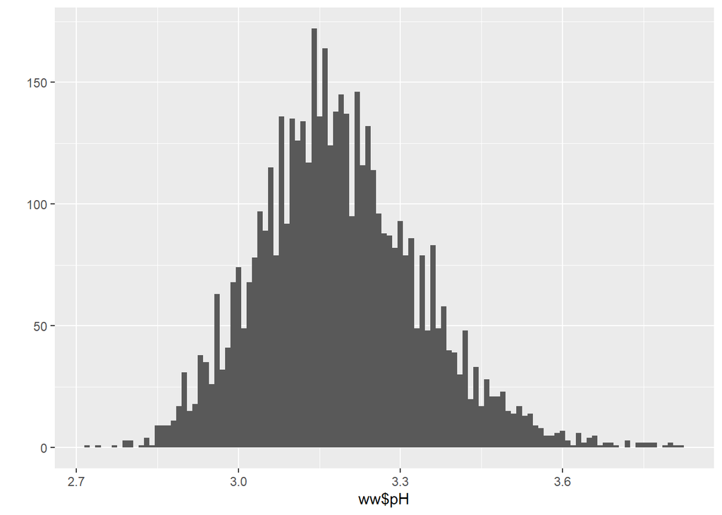

Really the only thing I’d potentially do to change pH is cut off those outliers on both ends, but I’m not even convinced it’s necessary at this point. Additionally, if I’m comparing pH with other variables, I’ll likely be paring the set a bit already.

### Sulphates

```
##    Min. 1st Qu.  Median    Mean 3rd Qu.    Max.
##  0.2200  0.4100  0.4700  0.4898  0.5500  1.0800
```

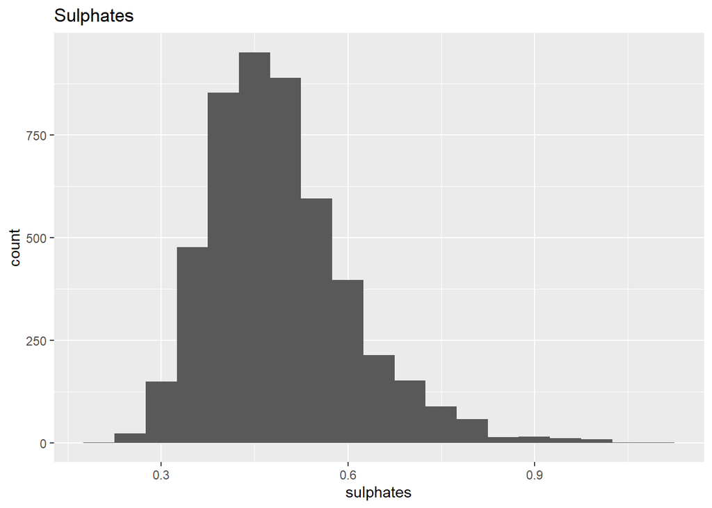

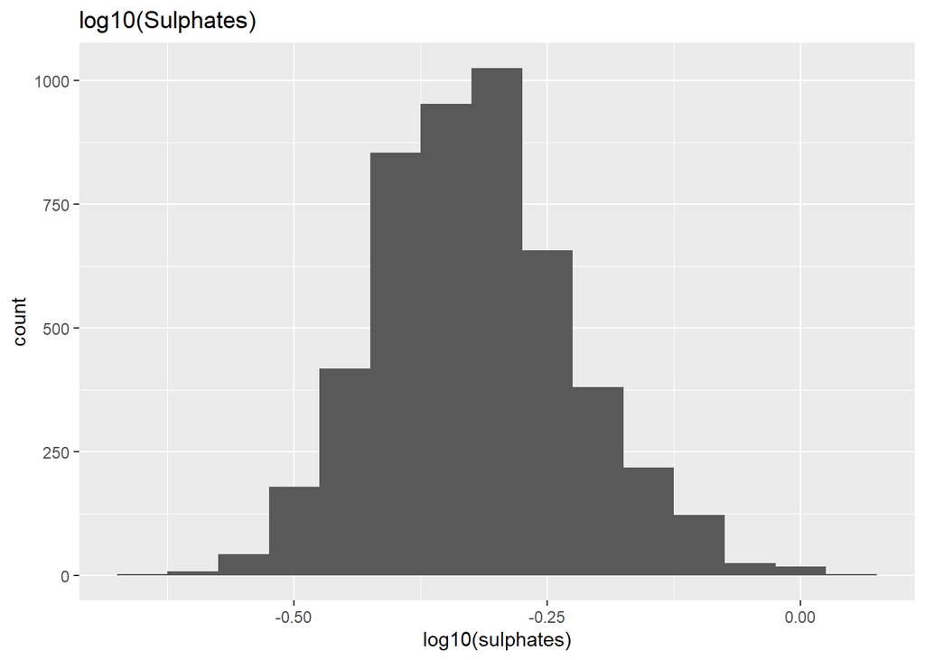

Without removing any data points from Sulphates, it can be taken from a normal distribution with a long tail to a pretty normal distribution using log10.

### Alcohol

```
##    Min. 1st Qu.  Median    Mean 3rd Qu.    Max.
##    8.00    9.50   10.40   10.51   11.40   14.20
```

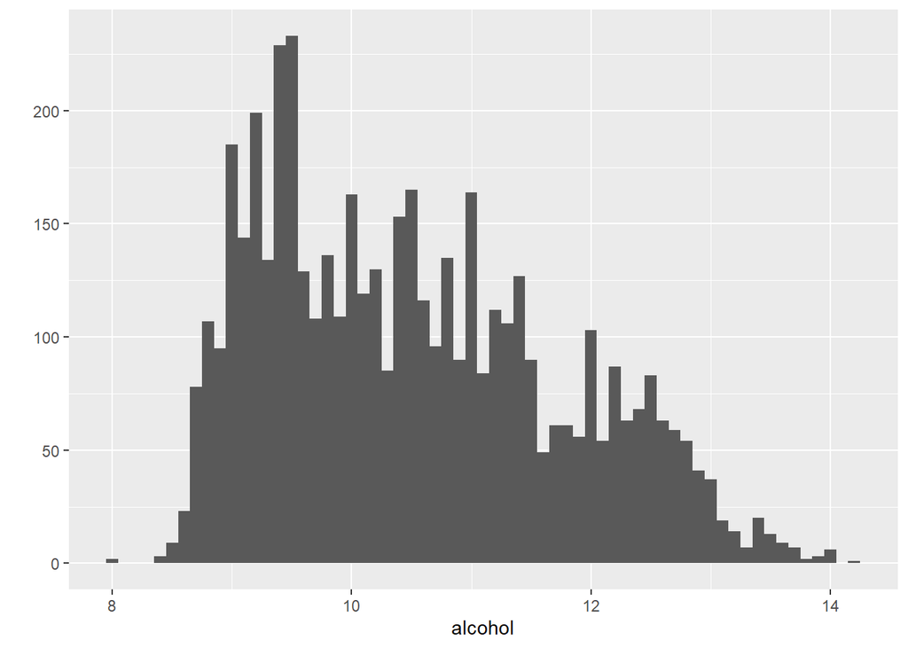

```
##
##    8  8.4  8.5  8.6  8.7  8.8  8.9    9  9.1  9.2  9.3  9.4  9.5  9.6  9.7
##    2    3    9   23   78  107   95  185  144  199  134  229  231  131  107
##  9.8  9.9   10 10.1 10.2 10.3 10.4 10.5 10.6 10.7 10.8 10.9   11 11.1 11.2
##  137  109  163  116  133   85  153  163  117   97  135   90  162   86  112
## 11.3 11.4 11.5 11.6 11.7 11.8 11.9   12 12.1 12.2 12.3 12.4 12.5 12.6 12.7
##  106  127   89   49   60   63   56  102   53   89   63   68   83   63   56
## 12.8 12.9   13 13.1 13.2 13.3 13.4 13.5 13.6 13.7 13.8 13.9   14 14.1 14.2
##   57   41   36   20   14    7   20   12   10    7    2    3    5    1    1
```

My delve into Alcohol will almost definitively benefit from binning later on, possibly by ones, but most likely by halves (8:8.4, 8.5:8.9, etc).

### Quality

```
##    Min. 1st Qu.  Median    Mean 3rd Qu.    Max.
##   3.000   5.000   6.000   5.878   6.000   9.000
```

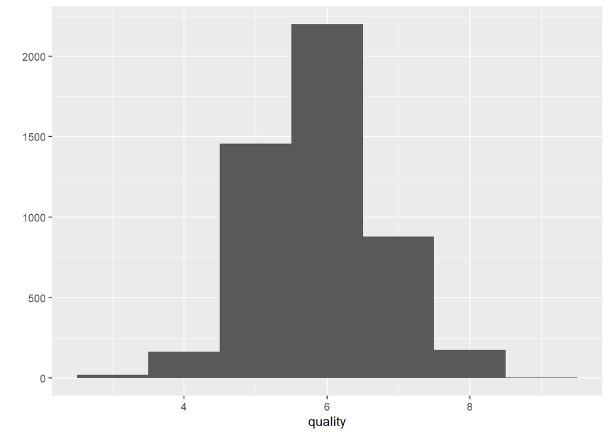

```
##
##    3    4    5    6    7    8    9
##   20  163 1457 2198  880  175    5
```

Clearly 6/10 is the most common quality rating, followed by 5, then 7. The reason I took an actual count was to see if 4 or 8 was higher, and it’s 8. No white wines received a score below 3 or above 9 (and only 5 got a score of 9).

# Univariate Analysis

> **Tip**: Now that you’ve completed your univariate explorations, it’s time to reflect on and summarize what you’ve found. Use the questions below to help you gather your observations and add your own if you have other thoughts!

### What is the structure of your dataset?

The white wine dataset holds 12 data points (technically 13, but one is just a record-identifying integer) for each of 4,898 records. 11 of these variables are numbers, the identifier is an integer, and the quality rating is an integer. That being the case, the values are pretty straight-forward.

### What is/are the main feature(s) of interest in your dataset?

investigation into your feature(s) of interest?

### Did you create any new variables from existing variables in the dataset?

### Of the features you investigated, were there any unusual distributions?

Did you perform any operations on the data to tidy, adjust, or change the form  
of the data? If so, why did you do this?

# Bivariate Plots Section

> **Tip**: Based on what you saw in the univariate plots, what relationships between variables might be interesting to look at in this section? Don’t limit yourself to relationships between a main output feature and one of the supporting variables. Try to look at relationships between supporting variables as well.

I was really excited to run this and see what I can see!

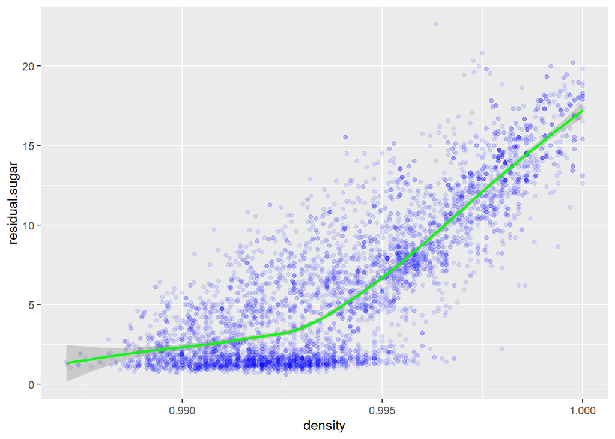

# Bivariate Analysis

> **Tip**: As before, summarize what you found in your bivariate explorations here. Use the questions below to guide your discussion.

investigation. How did the feature(s) of interest vary with other features in  
the dataset?

(not the main feature(s) of interest)?

### What was the strongest relationship you found?

# Multivariate Plots Section

> **Tip**: Now it’s time to put everything together. Based on what you found in the bivariate plots section, create a few multivariate plots to investigate more complex interactions between variables. Make sure that the plots that you create here are justified by the plots you explored in the previous section. If you plan on creating any mathematical models, this is the section where you will do that.

# Multivariate Analysis

investigation. Were there features that strengthened each other in terms of  
looking at your feature(s) of interest?

### Were there any interesting or surprising interactions between features?

strengths and limitations of your model.

# Final Plots and Summary

> **Tip**: You’ve done a lot of exploration and have built up an understanding of the structure of and relationships between the variables in your dataset. Here, you will select three plots from all of your previous exploration to present here as a summary of some of your most interesting findings. Make sure that you have refined your selected plots for good titling, axis labels (with units), and good aesthetic choices (e.g. color, transparency). After each plot, make sure you justify why you chose each plot by describing what it shows.

# Reflection

> **Tip**: Here’s the final step! Reflect on the exploration you performed and the insights you found. What were some of the struggles that you went through? What went well? What was surprising? Make sure you include an insight into future work that could be done with the dataset.

> **Tip**: Don’t forget to remove this, and the other **Tip** sections before saving your final work and knitting the final report!